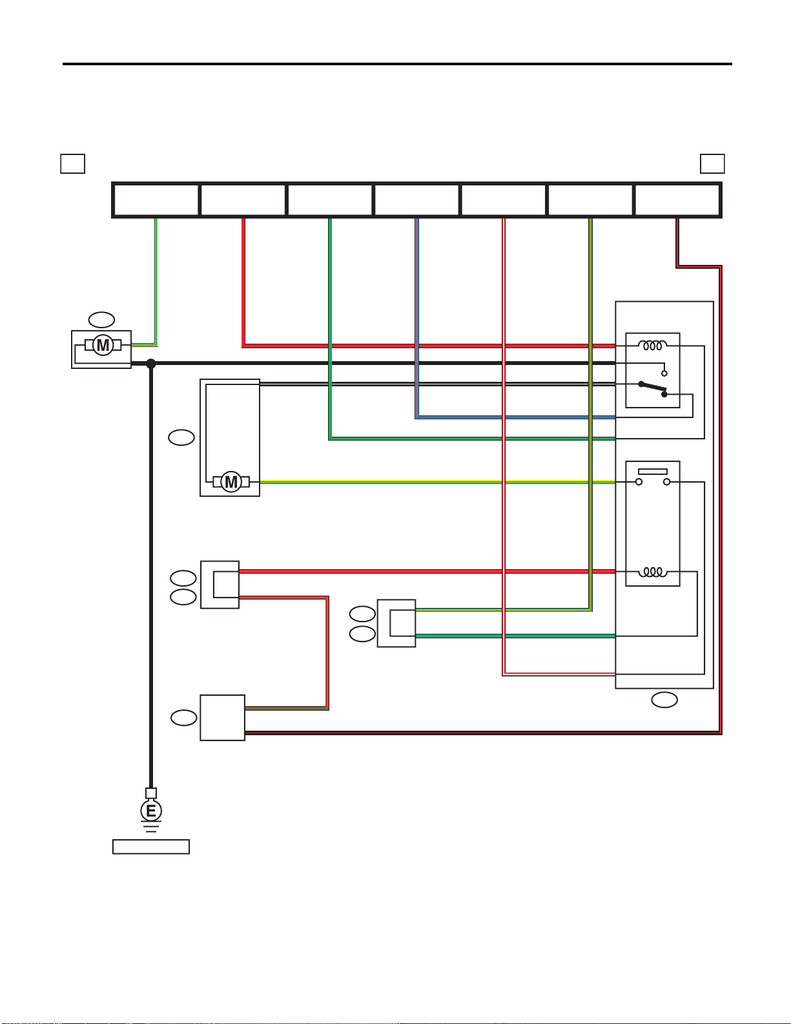

WI-340

Radiator Fan System

WIRING SYSTEM

39.Radiator Fan System

A: WIRING DIAGRAM

1. ENGINE TYPE FA

WI-44532

F108

A:

B361

D:

F109

B:

B360

C:

1a 1a

F27

F16

F17

A:

B134

R

Y/G

G

L/R

R/W

G/O

B/R

B

A37

A25

2

1

1 Y/G

B/W

B

2

B/R

R/G

D7

A16

B10

C1

R/G

R/L

G/L

G/O

R15

B13

B/W 12

L/R 14

G16

Y/G 18

R/L 19

R/W 17

G/L 20

ECM

MB-7

MAIN FAN RELAY 1

MAIN FAN

MOTOR

SUB FAN MOTOR

MAIN FAN

RELAY 2

SUB FAN

RELAY

THROUGH

JOINT CONNECTOR

RELAY HOLDER

MB-9

MAIN FAN RELAY 1

FB-46

F/B FUSE NO. 22

(IG)

MB-4

M/B FUSE NO. 3

(B)

MB-11

F/B FUSE NO. 26

(IG)

MB-8

MAIN FAN RELAY 1

MB-10

MAIN FAN RELAY 1

THROUGH

JOINT CONNECTOR

REF. TO GND [a]

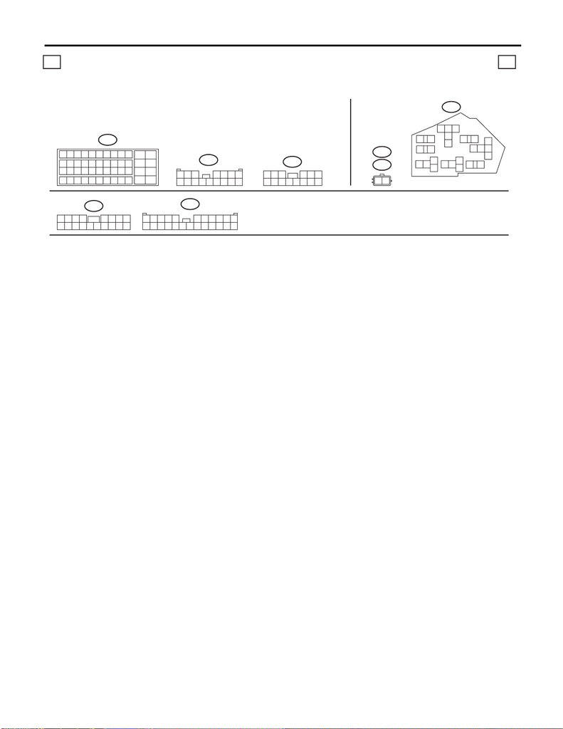

WI-341

Radiator Fan System

WIRING SYSTEM

F108

(GR)

1

9

23 8

10

4

11 12 13 14 15 16

567

17 18

A:

10 11

12 13 14 15 16 17 18 19 20 21 22 23 24

567

F109

B:

WI-44533

1b 1b

10

11 12

23 24

35 36

47 48

3

5

6

7894

12

45

21

2219 2017 1815 1613 14

33

3431 3229 3027 2825 26

(BR)

B134

A:

C:

(GR)

B360

123 4567

89

10 11 12 13 14 15 16

D:

(GR)

B361

123 456

789

10 11 12 13 14

F16

F17

12

F27

24

23

25

12 13 14

15

16

26

2221

20

19

1817

10 11

2

4

5

13

7698

LIST OF CONNECTORS

RELAY HOLDER

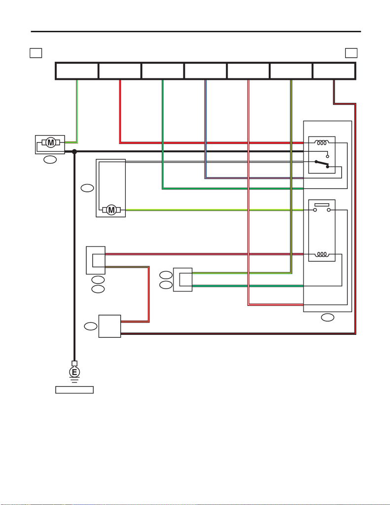

WI-342

Radiator Fan System

WIRING SYSTEM

2. ENGINE TYPE EJ

WI-44534

F108

A:

B361

D:

F109

B:

B360

C:

2a 2a

F27

F16

F17

B:

B135

R

Y/G

G

L/R

R/W

G/O

B/R

B

B12

B11

2

1

1 Y/G

B/W

B

2

B/R

R/G

D7

A16

B10

C1

R/G

R/L

G/L

G/O

R15

B13

B/W 12

L/R 14

G16

Y/G 18

R/L 19

R/W 17

G/L 20

ECM

MB-7

MAIN FAN RELAY 1

MAIN FAN

MOTOR

SUB FAN MOTOR

MAIN FAN

RELAY 2

SUB FAN

RELAY

THROUGH JOINT

CONNECTOR

RELAY HOLDER

MB-9

MAIN FAN RELAY 1

FB-46

F/B FUSE NO. 22

(IG)

MB-4

M/B FUSE NO. 3

(B)

MB-11

F/B FUSE NO. 26

(IG)

MB-8

MAIN FAN RELAY 1

MB-10

MAIN FAN RELAY 1

THROUGH JOINT

CONNECTOR

REF. TO GND [a]

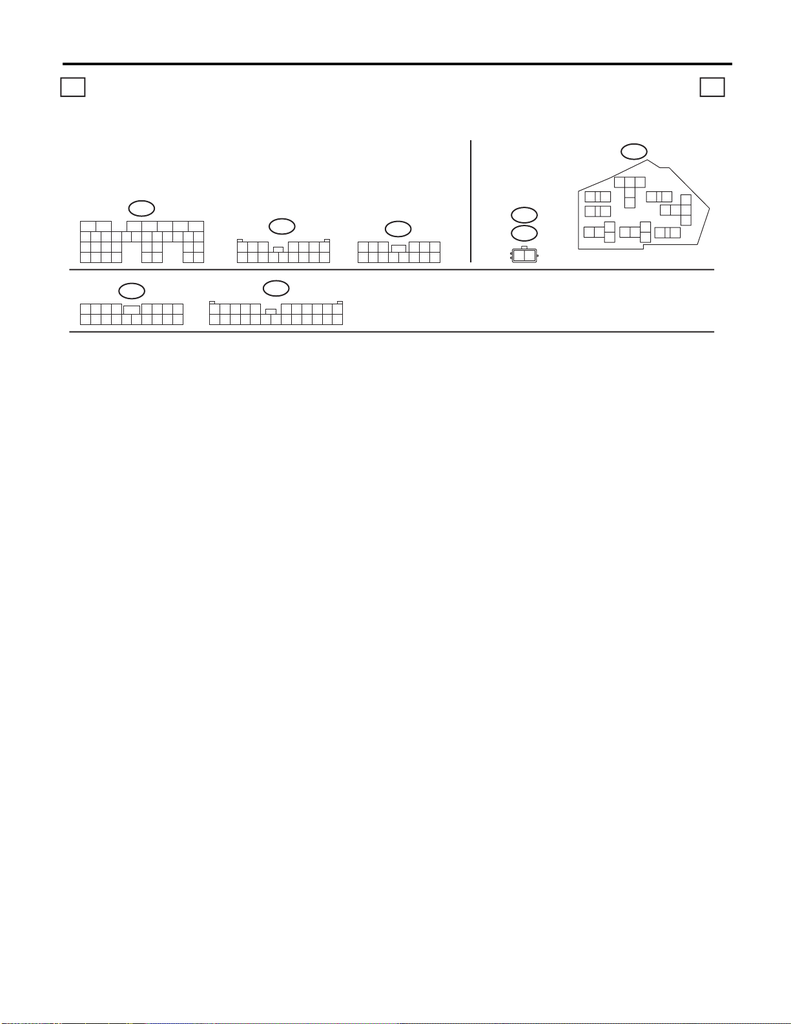

WI-343

Radiator Fan System

WIRING SYSTEM

F108

(GR)

1

9

23 8

10

4

11 12 13 14 15 16

567

17 18

A:

3412 89

10 11

12 13 14 15 16 17 18 19 20 21 22 23 24

567

F109

B:

WI-44535

2b 2b

C:

(GR)

B360

123 4567

89

10 11 12 13 14 15 16

D:

(GR)

B361

123 456

789

10 11 12 13 14

F16

F17

12

F27

24

23

25

12 13 14

15

16

26

2221

20

19

1817

10 11

2

4

5

13

7698

B135B:

29

10 11 12 13 14 15

2524

16

30

98

17 18 19

20

28

21 22 23

3231

26 27

33 34 35

LIST OF CONNECTORS

RELAY HOLDER